# Chapter 1

## Introduction

### Glossary

- **Reward**: a quantitative measure of success
- **Arm**: each arm is an option available to us
- **Bandit**: a collection of arms
- **Trial**: each chance you get to pull on an arm
- **Horizon**: the number of trials until the end of the current run
- **Exploitation**: pulling the arm with the currently highest estimated value
- **Exploration**: pulling the arm that doesn't have the currently highest estimated value
- **Exploration v Exploitation Dilemma**: the compromise between exploiting and exploring
- **Annealing**: exploring less over time
- **Temperature**: increasing temperature increases the exploration, decreasing temperature causes annealing
- **Streaming Algorithm**: an algorithm that can only process one data point at a time
- **Online Learning**: can only process one data point at a time and also provide results after each data point
- **Active Learning**: an algorithm that can decide which data point it wants to see next
- **Bernoulli**: outputs `1` with probability `p` and `0` with probability `1-p`

[figure not shown]

The multi-armed bandit problem is a problem in which a *gambler* is faced with multiple slot machines (see above) has to decide: which arms to pull, how many times to pull each arm and which order to pull them in. Each machine provides a reward (think: money) from a probability distribution specific to that machine. The objective of the gambler is to maximize the sum of rewards earned through a sequence of lever pulls.

Initially, the gambler has no knowledge about the machines. Thus, they face the *exploration v exploitation dilemma*, where they must *exploit* the machine they currently believe has the highest pay-out, while also *exploring* by pulling the arms of other machines to get more information about them. The exploration v exploitation dilemma is common in *reinforcement learning* tasks.

A real-world example for bandit algorithms is *A/B testing*. This is a method of comparing two versions of a web page to see which one performs better. Performance can be measured as the number of sales being made, or the longer users stay on the site. Each version of the page is an arm, and each user is a trial.

Why not have a period of pure exploration followed by a period of pure exploitation? During the exploration phase this will waste *resources*, i.e. sending people to a version of your site that gives less sales and thus losing you money.

We can define a bandit problem in 5 key points:

- We have $N$ potential options (arms)
- When pulled, an arm will give us a reward (this reward could be `0`)
- We start off with no knowledge of the reward rates for each arm
- We only get information about the arm we actually pulled
- If we pull an arm that isn't the best, in theory we lose reward as we could've pulled the best one

Bandit algorithms give you a set of *rules* for selecting arms in a certain sequence which has to balance learning about new arms, but also earning as much reward as possible by pulling on arms you already know are good.

## Epsilon-Greedy Bandit Algorithm

This is the most basic algorithm for the exploration v exploitation dilemma. A greedy algorithm is one that takes whatever actions seems best at the current time (i.e. exploitation) without caring about the long term consequences. However, the epsilon-greedy algorithm is one that randomly takes a random action (i.e. exploring) with probability $\epsilon$ (epsilon) and takes the currently valued highest action with probability $1-\epsilon$. Action here refers to pulling an arm.

The algorithm is implemented below:

```python
import random

class EpsilonGreedyBandit():
    def __init__(self, epsilon, arms):
        self.epsilon = epsilon
        self.arms = arms
        self.n_arms = len(self.arms)
        self.initialize()

    def initialize(self):
        self.pulls = [0 for _ in range(self.n_arms)]
        self.values = [0 for _ in range(self.n_arms)]

    def select_arm(self):
        if random.random() > self.epsilon:
            m = max(self.values)
            return self.values.index(m)
        else:
            return random.randrange(len(self.values))

    def update(self, chosen_arm, reward):
        self.pulls[chosen_arm] += 1
        n = self.pulls[chosen_arm]
        value = self.values[chosen_arm]
        new_value = ((n - 1) / n) * value + (1 / n) * reward
        self.values[chosen_arm] = new_value

    def get_reward(self, chosen_arm):
        if random.random() < self.arms[chosen_arm][0]:
            return self.arms[chosen_arm][1]
        else:
            return 0

    def pull(self):
        chosen_arm = self.select_arm()
        reward = self.get_reward(chosen_arm)
        self.update(chosen_arm, reward)
        return chosen_arm, reward
```

The $\epsilon$-greedy algorithm has the following parameters:

- `epsilon`: the frequency we should explore
- `arms`: a list of tuples containing (probability of reward, reward)
- `n_arms`: the number of arms
- `pulls`: counts how many times we have pulled each arm
- `values`: the average reward we have received for each arm

And the following functions:

```python
always_explore = EpsilonGreedyBandit(1, [(0.1, 100), (0.1, 50), (1, 5)])
always_exploit = EpsilonGreedyBandit(0, [(0.1, 100), (0.1, 50), (1, 5)])
```

The first bandit above will always explore (as $\epsilon = 1$), it will always pull an arm at random no matter what. The second will always exploit (as $\epsilon = 0$), it will pull the first arm it gets a reward from and never stop pulling that one arm.

The alternative is to have an $\epsilon$ value less than 1 but greater than 0.

However, consider what happens as you become more sure which arm is the best, your $\epsilon$ value never changes, so you will still be pulling one at random from time to time. Another problem is that initially your information about each arm will be limited, but you won't be exploring any more often at the start of a run than you will at the end!

We'll sort out those problems later though.

### Testing The Bandit Algorithm

Unlike machine learning systems, bandit algorithms are both *active learning* and *online learning* algorithms.

*Active learning* algorithms select which data they should receive.

*Online learning* algorithms analyse data in real-time and provide results after each data point.

The behaviour of the algorithm depends on the data it sees, but the data it sees depends on the behaviour of the algorithm! This means it's a bit more tricky to test bandit algorithms compared to standard machine learning algorithms.

The way we'll test is by using *Monte Carlo simulations*. This will allow us to provide data in real-time to the algorithm. As these simulations are noisy, we'll be running the simulations thousands of times in order to get more accurate results of the bandit algorithm's performance.

How do we analyse how well different values of $\epsilon$ work? Three main methods:

- The probability of choosing the best arm
- The average reward at each point in time
- The cumulative reward at each point in time

First, we'll make a function that takes in a bandit and returns the index of its best arm (calculated by multiplying the reward with the probability of receiving the reward).

```python
def get_best_arm(bandit):
    best_n, best_val = 0, 0
    for i, (prob, reward) in enumerate(bandit.arms):
        if prob*reward>best_val:
            best_n = i
            best_val = prob*reward
    return best_n
```

Next, we'll make a function that pulls a bandit's arm `n` times following its *policy* (i.e. its set of rules about which arm to pull).

Repeatedly pulling on an arm `n` times following a policy is called a *horizon*.

Here's a function that performs a horizon on a bandit.

```python
def run_horizon(bandit, horizon):

    best_arm = get_best_arm(bandit)
    cumulative_reward = 0
    best_arm_probs = []
    average_rewards = []
    cumulative_rewards = []

    for i in range(1,horizon+1):
        chosen_arm, reward = bandit.pull()
        cumulative_reward += reward
        average_reward = cumulative_reward/i
        best_arm_prob = bandit.pulls[best_arm]/i
        best_arm_probs.append(best_arm_prob)
        average_rewards.append(average_reward)
        cumulative_rewards.append(cumulative_reward)

    return best_arm_probs, average_rewards, cumulative_rewards
```

Let's have a look at some results with $\epsilon = 0.1$ and five arms.

Four of the arms give a reward of 1 with a probability of 0.1 and one (the best arm) gives a reward of 1 with a probability of 0.9.

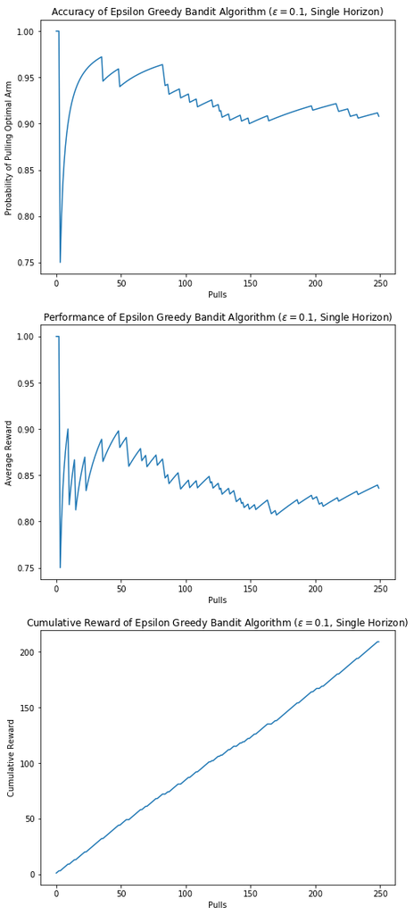

```python
import matplotlib.pyplot as plt

bandit = EpsilonGreedyBandit(0.1, [(0.1, 1), (0.1, 1), (0.1, 1), (0.1, 1), (0.9, 1)])

best_arm_probs, average_rewards, cumulative_rewards = run_horizon(bandit, 250)

fig = plt.figure(figsize=(8, 20))

fig.add_subplot(311)
plt.plot(best_arm_probs)
plt.title('Accuracy of Epsilon Greedy Bandit Algorithm ($\epsilon = 0.1$, Single Horizon)')
plt.xlabel('Pulls')
plt.ylabel('Probability of Pulling Optimal Arm')

fig.add_subplot(312)
plt.plot(average_rewards)
plt.title('Performance of Epsilon Greedy Bandit Algorithm ($\epsilon = 0.1$, Single Horizon)')
plt.xlabel('Pulls')
plt.ylabel('Average Reward')

fig.add_subplot(313)
plt.plot(cumulative_rewards)
plt.title('Cumulative Reward of Epsilon Greedy Bandit Algorithm ($\epsilon = 0.1$, Single Horizon)')
plt.xlabel('Pulls')
plt.ylabel('Cumulative Reward')

plt.show()
```

As mentioned before, the problem of analysing results from a single horizon a *noisy* due to the inherent randomness. By using Monte Carlo simulations (i.e. running the horizon multiple times) and averaging the results, we remove most of that noise and get clean results.

Below is a function that runs simulations:

```python
def run_simulation(bandit_algorithm, epsilon, arms, sims, horizon):

    best_arm_probs = [0. for _ in range(horizon)]
    average_rewards = [0. for _ in range(horizon)]
    cumulative_rewards = [0. for _ in range(horizon)]

    for s in range(sims):

        bandit = bandit_algorithm(epsilon, arms)

        h_best_arm_probs, h_average_rewards, h_cumulative_rewards = run_horizon(bandit, horizon)

        for i in range(horizon):
            best_arm_probs[i] = s/(s+1)*best_arm_probs[i]+1/(s+1)*h_best_arm_probs[i]
            average_rewards[i] = s/(s+1)*average_rewards[i]+1/(s+1)*h_average_rewards[i]
            cumulative_rewards[i] = s/(s+1)*cumulative_rewards[i]+1/(s+1)*h_cumulative_rewards[i]

    return best_arm_probs, average_rewards, cumulative_rewards
```

Now let's look at the results with the same parameters as before, but averaged out over 5000 horizons.

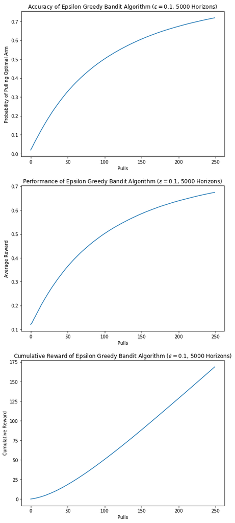

```python
epsilon = 0.1
arms = [(0.1, 1), (0.1, 1), (0.1, 1), (0.1, 1), (0.9, 1)]
simulations = 5000
horizon = 250

best_arm_probs, average_rewards, cumulative_rewards = run_simulation(EpsilonGreedyBandit, epsilon, arms, simulations, horizon)


fig = plt.figure(figsize=(8, 20))

fig.add_subplot(311)
plt.plot(best_arm_probs)
plt.title('Accuracy of Epsilon Greedy Bandit Algorithm ($\epsilon = 0.1$, 5000 Horizons)')
plt.xlabel('Pulls')
plt.ylabel('Probability of Pulling Optimal Arm')

fig.add_subplot(312)
plt.plot(average_rewards)
plt.title('Performance of Epsilon Greedy Bandit Algorithm ($\epsilon = 0.1$, 5000 Horizons)')
plt.xlabel('Pulls')
plt.ylabel('Average Reward')

fig.add_subplot(313)
plt.plot(cumulative_rewards)
plt.title('Cumulative Reward of Epsilon Greedy Bandit Algorithm ($\epsilon = 0.1$, 5000 Horizons)')
plt.xlabel('Pulls')
plt.ylabel('Cumulative Reward')

plt.show()
```

Finally, let's compare different values of $\epsilon$ against each other across 5000 horizons.

The function below is similar to `run_simulation`, but instead takes a list of $\epsilon$ values you want to run simulations on.

```python
def run_simulations(bandit_algorithm, epsilons, arms, sims, horizon):

    best_arm_probs = []
    average_rewards = []
    cumulative_rewards = []

    for e in epsilons:

        e_best_arm_probs = [0. for _ in range(horizon)]
        e_average_rewards = [0. for _ in range(horizon)]
        e_cumulative_rewards = [0. for _ in range(horizon)]

        for s in range(sims):

            bandit = bandit_algorithm(e, arms)

            h_best_arm_probs, h_average_rewards, h_cumulative_rewards = run_horizon(bandit, horizon)

            for i in range(horizon):
                e_best_arm_probs[i] = s/(s+1)*e_best_arm_probs[i]+1/(s+1)*h_best_arm_probs[i]
                e_average_rewards[i] = s/(s+1)*e_average_rewards[i]+1/(s+1)*h_average_rewards[i]
                e_cumulative_rewards[i] = s/(s+1)*e_cumulative_rewards[i]+1/(s+1)*h_cumulative_rewards[i]

        best_arm_probs.append(e_best_arm_probs)
        average_rewards.append(e_average_rewards)
        cumulative_rewards.append(e_cumulative_rewards)

    return best_arm_probs, average_rewards, cumulative_rewards
```

Now let's test it with $\epsilon$ values from 0 to 1 in increments of 0.1.

```python
epsilons = [0, 0.1, 0.2, 0.3, 0.4, 0.5, 0.6, 0.7, 0.8, 0.9, 1]

best_arm_probs, average_rewards, cumulative_rewards = run_simulations(EpsilonGreedyBandit, epsilons, arms, simulations, horizon)
```

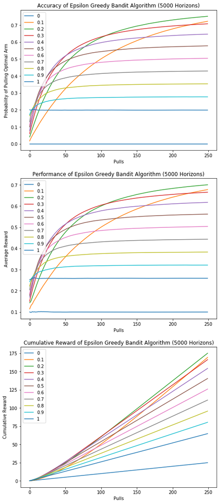

```python
fig = plt.figure(figsize=(8, 20))

fig.add_subplot(311)
for p in best_arm_probs:
    plt.plot(p)
plt.title('Accuracy of Epsilon Greedy Bandit Algorithm (5000 Horizons)')
plt.xlabel('Pulls')
plt.ylabel('Probability of Pulling Optimal Arm')
plt.legend(epsilons)

fig.add_subplot(312)
for p in average_rewards:
    plt.plot(p)
plt.title('Performance of Epsilon Greedy Bandit Algorithm (5000 Horizons)')
plt.xlabel('Pulls')
plt.ylabel('Average Reward')
plt.legend(epsilons)

fig.add_subplot(313)
for p in cumulative_rewards:
    plt.plot(p)
plt.title('Cumulative Reward of Epsilon Greedy Bandit Algorithm (5000 Horizons)')
plt.xlabel('Pulls')
plt.ylabel('Cumulative Reward')
plt.legend(epsilons)

plt.show()
```

As you can see, the two extremes of always explore and always exploit are the worst two strategies in every respect.

The best values of $\epsilon$ are between 0.1 and 0.3.

Can we do better? Of course! We'll explore improved bandit algorithms in the next chapter.